# James-Stein estimators

Author

[Michael Love](http://mikelove.github.io)

In this short document, I want to demonstrate the James-Stein estimator for a particular hierarchical model, and how it reduces *global error* compared to applying maximum likelihood estimation repeatedly. The model I will show is from the following article:

[Stein’s estimation rule and its competitors - an empirical Bayes approach](https://www.jstor.org/stable/2284155) by Bradley Efron and Carl Morris

The model is, suppose $k \ge 3$ parameters $\theta_1, ..., \theta_k$. For each $\theta_i$, we have a single observation $X_i$ drawn from the following distribution:

$$X_i \sim N(\theta_i, 1)$$

As stated in the article above, you can think of $X_i$ as the sample mean for *n* observations $Y_{ij} \sim N(\theta_i, \sigma^2)$, where then the above model scales such that $\sigma^2 / n = 1$. Furthermore we will assume that the $\theta$ are normally distributed with mean 0 and some unknown variance. The following chunk of code computes the James-Stein estimator given a value of *k* and the variance of the normal distribution for $\theta_i$. You can see that the James-Stein estimators move from the observed $x_i$ toward the middle, and that, over all the estimates for *B*, the James-Stein estimator tends to be close to the minimum.

However, seeing how this behaves over a range of values for `sigma.theta` is much more useful than just a fixed value. For this, the final code chunk uses the *manipulate* package, which works if you run it within RStudio. If you think of 1, the variance of $x_i$, as “noise”, and `sigma.theta` as how large the signal is, you can see that when noise is small relative to `sigma.theta` there is little shrinkage, while, when `sigma.theta` is small and the noise overwhelms the signal, the shrinkage toward 0 is large.

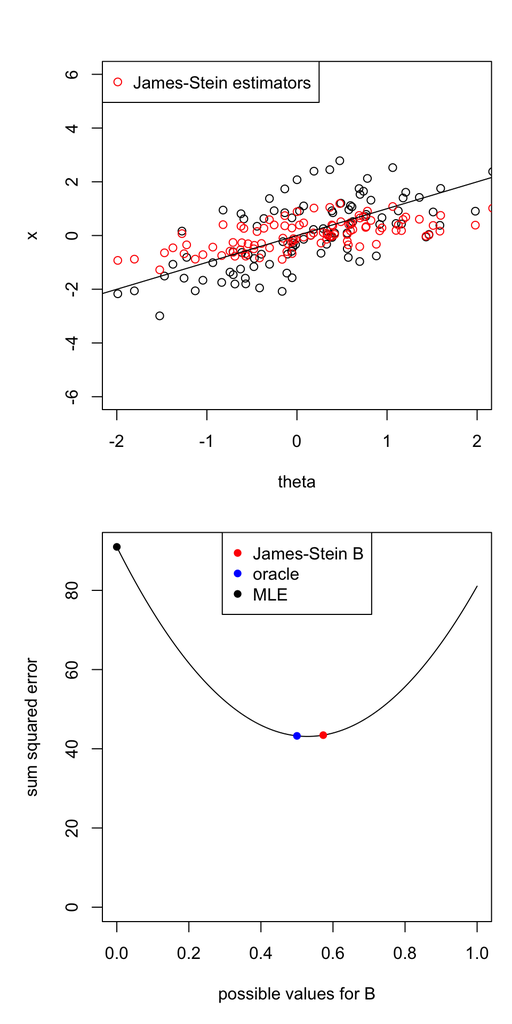

```r
k <- 100
sigma.theta <- 1
plotJS <- function(k, sigma.theta) {
  theta <- rnorm(k, 0, sigma.theta)
  # oracle estimator: what if we knew sigma_theta^2,
  # which Efron and Morris denote as 'A'
  B.oracle <- 1/(1 + sigma.theta^2)
  x <- rnorm(k, theta, 1)
  B <- (k - 2)/sum(x^2)
  eb <- (1 - B) * x
  oracle <- (1 - B.oracle) * x
  par(mfrow=c(2,1), mar=c(5,5,3,1))
  plot(theta, x, xlim=c(-2*sigma.theta,2*sigma.theta), ylim=c(-6,6))
  points(theta, eb, col="red")
  abline(0,1)
  legend("topleft","James-Stein estimators",col="red",pch=1)
  s <- seq(from=0,to=1,length=100)
  par(mar=c(5,5,1,1))
  sse.f <- function(b) sum((theta - (1 - b)*x)^2)
  sse <- sapply(s, sse.f)
  plot(s, sse, ylim=c(0, max(sse)), type="l",
       xlab="possible values for B", ylab="sum squared error")
  points(B, sum((theta - eb)^2), col="red", pch=16)
  points(B.oracle, sum((theta - oracle)^2), col="blue", pch=16)
  points(0, sse[1], col="black", pch=16)
  legend("top",c("James-Stein B","oracle","MLE"), col=c("red","blue","black"), pch=16)
}
set.seed(1)
plotJS(k, sigma.theta)
```

# Manipulate sigma.theta

```r
library(manipulate)
manipulate(plotJS(k, sigma.theta), sigma.theta = slider(.1,2))
```